# Project: Investigate a Dataset (Patient No Show Appointments May 2016.csv)

- Introduction
- Data Wrangling
- Exploratory Data Analysis
- Conclusions

## Introduction

This dataset collects information from 100k medical appointments in Brazil and is focused on the question of whether or not patients show up for their appointment. A number of characteristics about the patient are included in each row.

● ‘ScheduledDay’ tells us on what day the patient set up their appointment.

● ‘Neighborhood’ indicates the location of the hospital.

● ‘Scholarship’ indicates whether or not the patient is enrolled in Brasilian welfare program Bolsa Família.

● Be careful about the encoding of the last column: it says ‘No’ if the patient showed up to their appointment, and ‘Yes’ if the patient did not show up

## Describtion of the Dataset

I am going to use a CSV file which contains the data I am going to use.

## Questions for Analysis

What are the factors to consider in order to know weather a patient is going to show up for his/her appointment.

```python
import pandas as pd
import numpy as np
import matplotlib.pyplot as plt
import seaborn as snb
%matplotlib inline
```

## Data Wrangling

### General Properties

```python
df=pd.read_csv('KaggleV2-May-2016.csv')
df.head()
```

|  | PatientId | AppointmentID | Gender | ScheduledDay | AppointmentDay | Age | Neighbourhood | Scholarship | Hipertension | Diabetes | Alcoholism | Handcap | SMS_received | No-show |
| --- | --- | --- | --- | --- | --- | --- | --- | --- | --- | --- | --- | --- | --- | --- |
| 0 | 2.987250e+13 | 5642903 | F | 2016-04-29T18:38:08Z | 2016-04-29T00:00:00Z | 62 | JARDIM DA PENHA | 0 | 1 | 0 | 0 | 0 | 0 | No |
| 1 | 5.589978e+14 | 5642503 | M | 2016-04-29T16:08:27Z | 2016-04-29T00:00:00Z | 56 | JARDIM DA PENHA | 0 | 0 | 0 | 0 | 0 | 0 | No |
| 2 | 4.262962e+12 | 5642549 | F | 2016-04-29T16:19:04Z | 2016-04-29T00:00:00Z | 62 | MATA DA PRAIA | 0 | 0 | 0 | 0 | 0 | 0 | No |
| 3 | 8.679512e+11 | 5642828 | F | 2016-04-29T17:29:31Z | 2016-04-29T00:00:00Z | 8 | PONTAL DE CAMBURI | 0 | 0 | 0 | 0 | 0 | 0 | No |
| 4 | 8.841186e+12 | 5642494 | F | 2016-04-29T16:07:23Z | 2016-04-29T00:00:00Z | 56 | JARDIM DA PENHA | 0 | 1 | 1 | 0 | 0 | 0 | No |

```python
# Exploring the shape of the dataset
df.shape
```

```
(110527, 14)
```

The dataset has 110527 rows and 14 colums

```python
# Getting more information about the dataset
df.describe()
```

|  | PatientId | AppointmentID | Age | Scholarship | Hipertension | Diabetes | Alcoholism | Handcap | SMS_received |
| --- | --- | --- | --- | --- | --- | --- | --- | --- | --- |
| count | 1.105270e+05 | 1.105270e+05 | 110527.000000 | 110527.000000 | 110527.000000 | 110527.000000 | 110527.000000 | 110527.000000 | 110527.000000 |
| mean | 1.474963e+14 | 5.675305e+06 | 37.088874 | 0.098266 | 0.197246 | 0.071865 | 0.030400 | 0.022248 | 0.321026 |
| std | 2.560949e+14 | 7.129575e+04 | 23.110205 | 0.297675 | 0.397921 | 0.258265 | 0.171686 | 0.161543 | 0.466873 |
| min | 3.921784e+04 | 5.030230e+06 | -1.000000 | 0.000000 | 0.000000 | 0.000000 | 0.000000 | 0.000000 | 0.000000 |
| 25% | 4.172614e+12 | 5.640286e+06 | 18.000000 | 0.000000 | 0.000000 | 0.000000 | 0.000000 | 0.000000 | 0.000000 |
| 50% | 3.173184e+13 | 5.680573e+06 | 37.000000 | 0.000000 | 0.000000 | 0.000000 | 0.000000 | 0.000000 | 0.000000 |
| 75% | 9.439172e+13 | 5.725524e+06 | 55.000000 | 0.000000 | 0.000000 | 0.000000 | 0.000000 | 0.000000 | 1.000000 |
| max | 9.999816e+14 | 5.790484e+06 | 115.000000 | 1.000000 | 1.000000 | 1.000000 | 1.000000 | 4.000000 | 1.000000 |

This is the summary statistics of the dataset; it gives us an insight into tha statistics of the dataset. If you notice you'll see -1 as the min of age which is an error; the next cell will query that error.

```python
# Checking -1 min age
mask=df.query('Age=="-1"')
mask
```

|  | PatientId | AppointmentID | Gender | ScheduledDay | AppointmentDay | Age | Neighbourhood | Scholarship | Hipertension | Diabetes | Alcoholism | Handcap | SMS_received | No-show |
| --- | --- | --- | --- | --- | --- | --- | --- | --- | --- | --- | --- | --- | --- | --- |

```python
# Getting infomation on missing data
df.info()
```

```
<class 'pandas.core.frame.DataFrame'>
RangeIndex: 110527 entries, 0 to 110526
Data columns (total 14 columns):
 #   Column          Non-Null Count   Dtype
---  ------          --------------   -----
 0   PatientId       110527 non-null  float64
 1   AppointmentID   110527 non-null  int64
 2   Gender          110527 non-null  object
 3   ScheduledDay    110527 non-null  object
 4   AppointmentDay  110527 non-null  object
 5   Age             110527 non-null  int64
 6   Neighbourhood   110527 non-null  object
 7   Scholarship     110527 non-null  int64
 8   Hipertension    110527 non-null  int64
 9   Diabetes        110527 non-null  int64
 10  Alcoholism      110527 non-null  int64
 11  Handcap         110527 non-null  int64
 12  SMS_received    110527 non-null  int64
 13  No-show         110527 non-null  object
dtypes: float64(1), int64(8), object(5)
memory usage: 11.8+ MB
```

The .info function shnows a metadata of the dataset showing types, number of rows and colums, colum names etc. it helps us to norrow down the content of the dataset and understand it's structure and shape.

```python
# Showing the types of data contain by each colum
df.dtypes
```

```
PatientId         float64
AppointmentID       int64
Gender             object
ScheduledDay       object
AppointmentDay     object
Age                 int64
Neighbourhood      object
Scholarship         int64
Hipertension        int64
Diabetes            int64
Alcoholism          int64
Handcap             int64
SMS_received        int64
No-show            object
dtype: object
```

The dtypes function shows us the type of each colum specifically. You may see that there are no 'strings' in the types; that is because python recognize and stores 'strings' as object; so where we see 'object' we'll it's a string.

```python
# Checking for duplicated values
df.duplicated().sum()
```

```
0
```

There are no duplicated values in the dataset

```python
# Checking for unique values in the dataset
df.nunique()
```

```
PatientId          62299
AppointmentID     110527
Gender                 2
ScheduledDay      103549
AppointmentDay        27
Age                  104
Neighbourhood         81
Scholarship            2
Hipertension           2
Diabetes               2
Alcoholism             2
Handcap                5
SMS_received           2
No-show                2
dtype: int64
```

```python
# Checking for unique patient id
df['PatientId'].nunique()
```

```
62299
```

There are 62299 out of 110527 unique patient Id

```python
# Checking for duplicated patient Id
df['PatientId'].duplicated().sum()
```

```
48228
```

There are 48228 duplicated patient Id

## Data Cleaning Stage

```python
# Dropping the -1 value in the Age colum of the dataset
df.drop(index=99832, inplace=True)
df.describe()
```

|  | PatientId | AppointmentID | Age | Scholarship | Hipertension | Diabetes | Alcoholism | Handcap | SMS_received |
| --- | --- | --- | --- | --- | --- | --- | --- | --- | --- |
| count | 1.105260e+05 | 1.105260e+05 | 110526.000000 | 110526.000000 | 110526.000000 | 110526.000000 | 110526.000000 | 110526.000000 | 110526.000000 |
| mean | 1.474934e+14 | 5.675304e+06 | 37.089219 | 0.098266 | 0.197248 | 0.071865 | 0.030400 | 0.022248 | 0.321029 |
| std | 2.560943e+14 | 7.129544e+04 | 23.110026 | 0.297676 | 0.397923 | 0.258266 | 0.171686 | 0.161543 | 0.466874 |
| min | 3.921784e+04 | 5.030230e+06 | 0.000000 | 0.000000 | 0.000000 | 0.000000 | 0.000000 | 0.000000 | 0.000000 |
| 25% | 4.172536e+12 | 5.640285e+06 | 18.000000 | 0.000000 | 0.000000 | 0.000000 | 0.000000 | 0.000000 | 0.000000 |
| 50% | 3.173184e+13 | 5.680572e+06 | 37.000000 | 0.000000 | 0.000000 | 0.000000 | 0.000000 | 0.000000 | 0.000000 |
| 75% | 9.438963e+13 | 5.725523e+06 | 55.000000 | 0.000000 | 0.000000 | 0.000000 | 0.000000 | 0.000000 | 1.000000 |
| max | 9.999816e+14 | 5.790484e+06 | 115.000000 | 1.000000 | 1.000000 | 1.000000 | 1.000000 | 4.000000 | 1.000000 |

```python
# Correcting colum names
df.rename(columns={'Hipertension':'Hypertension'}, inplace= True)
df.rename(columns={'No-show':'No_Show'}, inplace= True)
df.head()
```

|  | PatientId | AppointmentID | Gender | ScheduledDay | AppointmentDay | Age | Neighbourhood | Scholarship | Hypertension | Diabetes | Alcoholism | Handcap | SMS_received | No_Show |
| --- | --- | --- | --- | --- | --- | --- | --- | --- | --- | --- | --- | --- | --- | --- |
| 0 | 2.987250e+13 | 5642903 | F | 2016-04-29T18:38:08Z | 2016-04-29T00:00:00Z | 62 | JARDIM DA PENHA | 0 | 1 | 0 | 0 | 0 | 0 | No |
| 1 | 5.589978e+14 | 5642503 | M | 2016-04-29T16:08:27Z | 2016-04-29T00:00:00Z | 56 | JARDIM DA PENHA | 0 | 0 | 0 | 0 | 0 | 0 | No |
| 2 | 4.262962e+12 | 5642549 | F | 2016-04-29T16:19:04Z | 2016-04-29T00:00:00Z | 62 | MATA DA PRAIA | 0 | 0 | 0 | 0 | 0 | 0 | No |
| 3 | 8.679512e+11 | 5642828 | F | 2016-04-29T17:29:31Z | 2016-04-29T00:00:00Z | 8 | PONTAL DE CAMBURI | 0 | 0 | 0 | 0 | 0 | 0 | No |
| 4 | 8.841186e+12 | 5642494 | F | 2016-04-29T16:07:23Z | 2016-04-29T00:00:00Z | 56 | JARDIM DA PENHA | 0 | 1 | 1 | 0 | 0 | 0 | No |

As you can see the column names for 'Hipertension' and 'No-show' has been corrected and change to 'Hypertention' and 'No_SHow' respectively.

```python
# Removing duplicates values
df.drop_duplicates(['PatientId', 'No_Show'], inplace= True)
df.shape
```

```
(71816, 14)
```

The duplicated values have been droped from 110526 rows to 71816 rows

```python
# Renoving unnecessary data
df.drop(['PatientId', 'AppointmentID', 'ScheduledDay', 'AppointmentDay'], axis=1, inplace= True)
df.head()
```

|  | Gender | Age | Neighbourhood | Scholarship | Hypertension | Diabetes | Alcoholism | Handcap | SMS_received | No_Show |
| --- | --- | --- | --- | --- | --- | --- | --- | --- | --- | --- |
| 0 | F | 62 | JARDIM DA PENHA | 0 | 1 | 0 | 0 | 0 | 0 | No |
| 1 | M | 56 | JARDIM DA PENHA | 0 | 0 | 0 | 0 | 0 | 0 | No |
| 2 | F | 62 | MATA DA PRAIA | 0 | 0 | 0 | 0 | 0 | 0 | No |
| 3 | F | 8 | PONTAL DE CAMBURI | 0 | 0 | 0 | 0 | 0 | 0 | No |
| 4 | F | 56 | JARDIM DA PENHA | 0 | 1 | 1 | 0 | 0 | 0 | No |

## Data Wrangling Summary

In this stage I was able to gather my Data from a CSV file and explore the first few rows to see the sturcture of my data and it's general properties. I was able to see the dimention of the data, checked the data for duplicated values, missing values and possible errors; I found some duplicated values in the 'PatiendId' column and remove them. checked the dataset type to see if there are any furthr missing data to handle. And lastly I was able to see some statistical information about my data on min, max, and mean. And finally I cleaned my data by removing duplicates, unnecessary data, correcting the columns names and dropping unnecessary columns.

## Exploratory Data Analysis

Now that I have trimmed and cleaned my data, it's time to move on to exploration. Computing statistics and creating visualizations with the goal of addressing the research questions that I posed in the Introduction section.

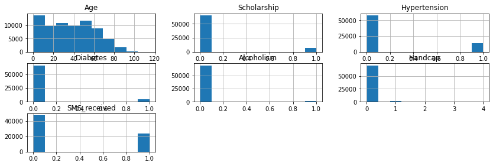

```python
# Creating visualization of the columns using histogram
df.hist(figsize=(14,4.3));
```

```python
# Deviding the patient in to two (2) groups 'show' and 'noshow' and exploring them
show = df.No_Show == 'No'
noshow = df.No_Show == 'Yes'
df[show].count(), df[noshow].count()
```

```
(Gender           54153
 Age              54153
 Neighbourhood    54153
 Scholarship      54153
 Hypertension     54153
 Diabetes         54153
 Alcoholism       54153
 Handcap          54153
 SMS_received     54153
 No_Show          54153
 dtype: int64,
 Gender           17663
 Age              17663
 Neighbourhood    17663
 Scholarship      17663
 Hypertension     17663
 Diabetes         17663
 Alcoholism       17663
 Handcap          17663
 SMS_received     17663
 No_Show          17663
 dtype: int64)
```

The Number of showed is 54153 which is greater than number of no show 17663

```python
# Getting the mean of both groups
df[show].mean(), df[noshow].mean()
```

```
(Age             37.229166
 Scholarship      0.091334
 Hypertension     0.202944
 Diabetes         0.072868
 Alcoholism       0.023600
 Handcap          0.020904
 SMS_received     0.297232
 dtype: float64,
 Age             34.376267
 Scholarship      0.108419
 Hypertension     0.170922
 Diabetes         0.065108
 Alcoholism       0.029440
 Handcap          0.017777
 SMS_received     0.453094
 dtype: float64)
```

Mean age for show is 37 and the mean age for noshow is 34, but the SMS_received mean of noshow is higher than that of show whnich means that we need to look into our messaging strategies.

## Investigation for the Influencing Factors on the Attendance Rate

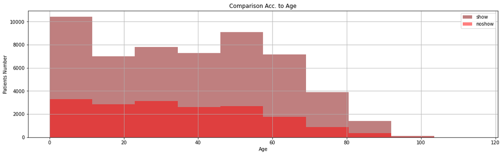

```python
# Does Age Affect the Attendance?
def attendance(df, col_name, attended, absent): # Setting

    plt.figure(figsize= [18,5])
    df[col_name][show].hist(alpha=.5, bins=10, color='maroon', label='show')
    df[col_name][noshow].hist(alpha=.5, bins=10, color='red', label='noshow')
    plt.legend();
    plt.title('Comparison Acc. to Age')
    plt.xlabel('Age')
    plt.ylabel('Patients Number');
attendance(df, 'Age', show,noshow)
```

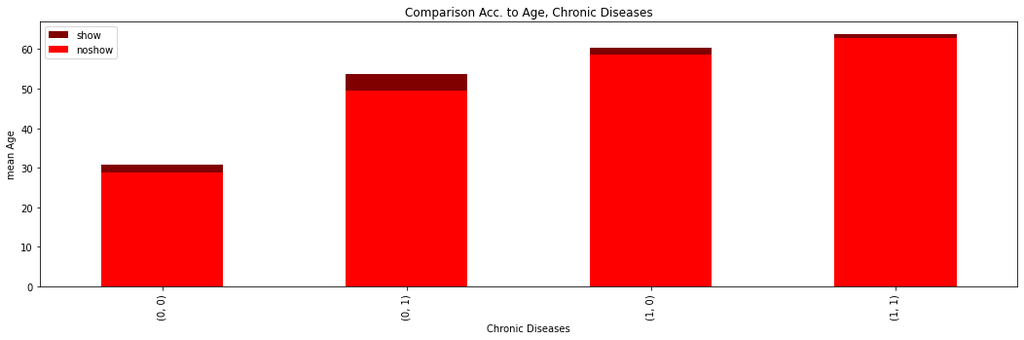

```python
# Checking if Age and Chronic diseases affect the attendance
plt.figure(figsize=[18,5])
df[show].groupby(['Hypertension', 'Diabetes']).mean()['Age'].plot(kind= 'bar', color= 'maroon', label= 'show')
df[noshow].groupby(['Hypertension', 'Diabetes']).mean()['Age'].plot(kind= 'bar', color= 'red', label= 'noshow')
plt.legend();
plt.title('Comparison Acc. to Age, Chronic Diseases')
plt.xlabel('Chronic Diseases')
plt.ylabel('mean Age')
```

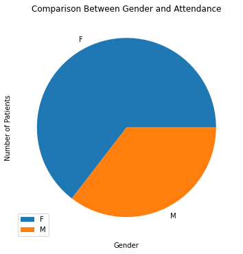

```python
# Checking if gender affect the attendance (Checking for attended gender)
def attendance(df, col_name, attended, absent):
    plt.figure(figsize= [14,6])
    df[col_name][show].value_counts(normalize= True).plot(kind= 'pie', label= 'show')
    plt.legend();
    plt.title('Comparison Between Gender and Attendance')
    plt.xlabel('Gender')
    plt.ylabel('Number of Patients')
attendance(df, 'Gender', show, noshow)
```

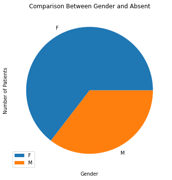

```python
# Checking if gender affect the attendance (Checking for absent gender)
def attendance(df, col_name, attended, absent):
    plt.figure(figsize= [14,6])
    df[col_name][show].value_counts(normalize= True).plot(kind= 'pie', label= 'noshow')
    plt.legend();
    plt.title('Comparison Between Gender and Absent')
    plt.xlabel('Gender')
    plt.ylabel('Number of Patients')
attendance(df, 'Gender', noshow, show)
```

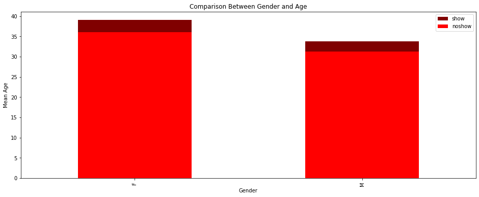

```python
# Checking for comparison between gender and age
plt.figure(figsize= [16,6]) # Setting fig. size
df[show].groupby('Gender').Age.mean().plot(kind= 'bar', color= 'maroon', label= 'show')
df[noshow].groupby('Gender').Age.mean().plot(kind= 'bar', color= 'red', label= 'noshow')
plt.legend();
plt.title('Comparison Between Gender and Age')
plt.xlabel('Gender')
plt.ylabel('Mean Age');
```

```python
print(df[show].groupby('Gender').Age.mean(), df[noshow].groupby('Gender').Age.mean())
print( df[show].groupby('Gender').Age.median(), df[noshow].groupby('Gender').Age.median())
```

```
Gender
F    39.130292
M    33.766269
Name: Age, dtype: float64 Gender
F    36.06501
M    31.22040
Name: Age, dtype: float64
Gender
F    39.0
M    32.0
Name: Age, dtype: float64 Gender
F    34.0
M    29.0
Name: Age, dtype: float64
```

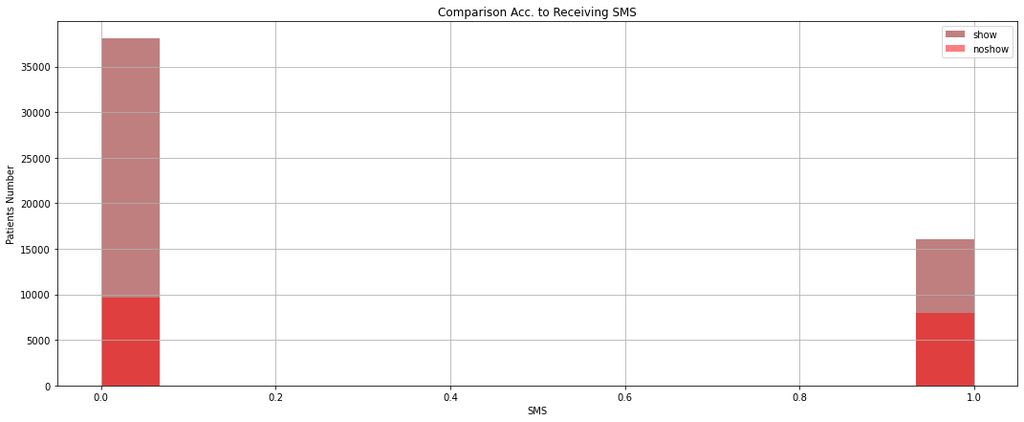

```python
# Does Receiving SMS affect the attendance
def attendance(df, col_name, attended, absent):
    plt.figure(figsize= [18,7])
    df[col_name][show].hist(alpha=.5, bins= 15, color= 'maroon', label= 'show')
    df[col_name][noshow].hist(alpha=.5, bins= 15, color= 'red', label= 'noshow')
    plt.legend();
    plt.title('Comparison Acc. to Receiving SMS')
    plt.xlabel('SMS')
    plt.ylabel('Patients Number')
attendance(df, 'SMS_received', show, noshow)
```

The number of patient showing withouth receiving SMS is higher than those whowing after receiving SMS.

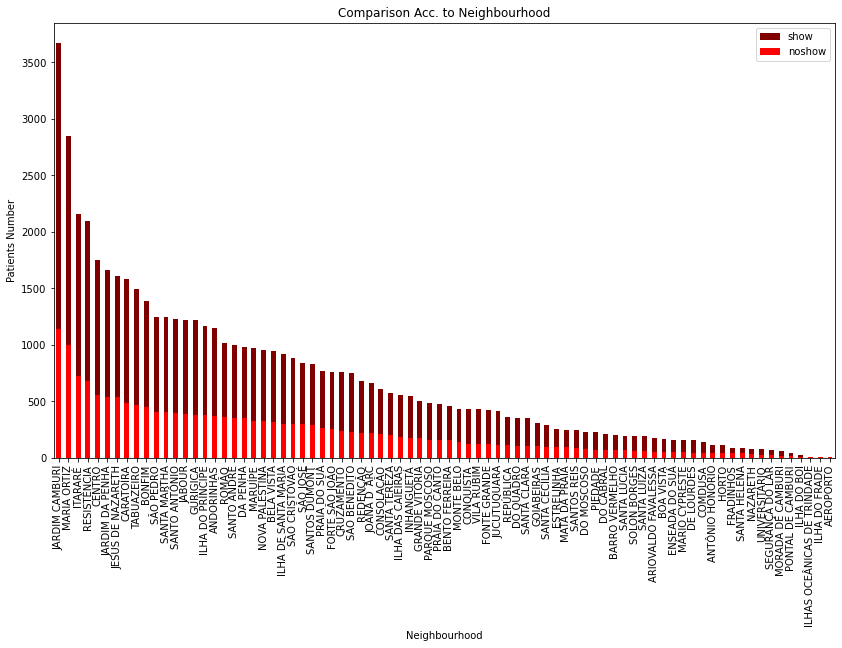

```python
# Checking if the Neighbourhood affect the attendance
plt.figure(figsize= [14,8]) # Setting fig. size
df.Neighbourhood[show].value_counts().plot(kind= 'bar', color= 'maroon', label= 'show')
df.Neighbourhood[noshow].value_counts().plot(kind= 'bar', color= 'red', label= 'noshow')
plt.legend();
plt.title('Comparison Acc. to Neighbourhood')
plt.xlabel('Neighbourhood')
plt.ylabel('Patients Number');
```

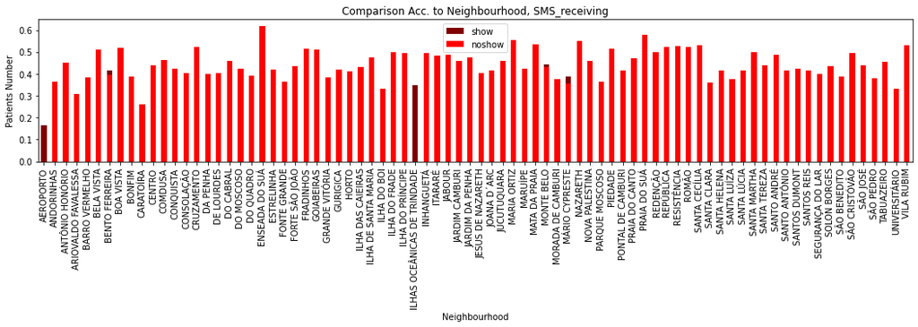

```python
# Checking Comparison between Neighnourhood and SMS_receiving mean.
plt.figure(figsize= [18,3]) # Setting fig size
df[show].groupby('Neighbourhood').SMS_received.mean().plot(kind= 'bar', color= 'maroon', label= 'show')
df[noshow].groupby('Neighbourhood').SMS_received.mean().plot(kind= 'bar', color= 'red', label= 'noshow')
plt.legend();
plt.title('Comparison Acc. to Neighbourhood, SMS_receiving')
plt.xlabel('Neighbourhood')
plt.ylabel('Patients Number');
```

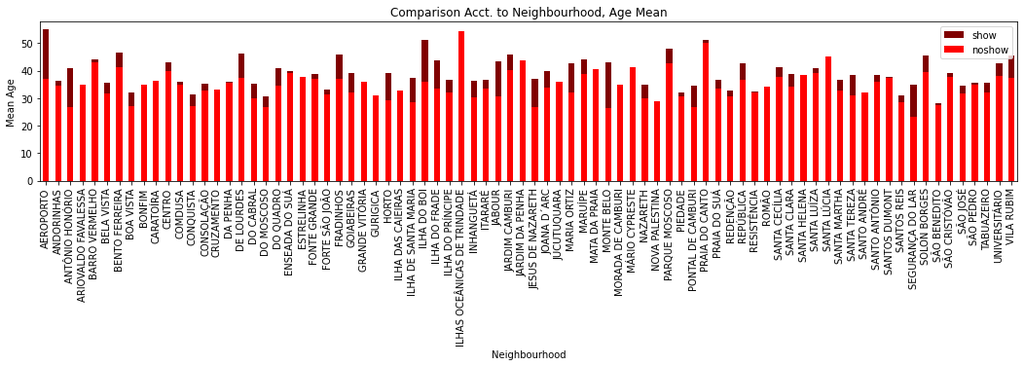

```python
# Checking comparison between Neighbourhood and Age mean
plt.figure(figsize=[18,3]) # Setting fig. size
df[show].groupby('Neighbourhood').Age.mean().plot(kind= 'bar', color= 'maroon', label= 'show')
df[noshow].groupby('Neighbourhood').Age.mean().plot(kind= 'bar', color= 'red', label= 'noshow')
plt.legend();
plt.title('Comparison Acct. to Neighbourhood, Age Mean')
plt.xlabel('Neighbourhood')
plt.ylabel('Mean Age');
```

## Conclusions

Lastly I noticed that the number of showing patient by SMS received is lower than those without receiving the SMS. This shows that we need to revist our SMS sending strategy.

## Limitations

Thers is no clear correlation between showing and chronic diseases, gender and enrolment in the walfare program.